# descriptive_statistics

### Title: Impact of Education and GDP on Adolescent Fertility

### Authors: Anna Huang, Rola Ke, Sissi Li, Vicki Lin, Chrissy Wang

### Research Question: Do higher education levels and GDP per capita contribute to lower adolescent fertility rates across countries?

### **INTRODUCTION** :

The relationship between economic prosperity and demographic outcomes has long been a focal point of global development studies. Adolescent fertility is a critical indicator of both gender equality and social mobility, often reflecting the accessibility of human capital resources like education. This project investigates how national wealth (GDP per capita) and educational attainment influence the reproductive health landscapes of six diverse nations: Brazil, Switzerland, Italy, Malaysia, Niger, and India.

These countries were selected to represent a broad spectrum of the global development hierarchy. Switzerland and Italy represent high-income, established economies with robust social infrastructures and high educational enrollment. Brazil and Malaysia serve as middle-income emerging powers navigating significant socio-economic transitions. In contrast, India and Niger represent developing contexts; India is a rapidly expanding economy with heterogeneous development outcomes, while Niger faces unique demographic challenges, consistently recording some of the highest fertility rates globally. By comparing these varying structures, we aim to understand the extent to which wealth and schooling act as buffers against early childbearing.

### **DATA DESCRIPTION:**

We utilize data from the World Bank’s World Development Indicators (WDI) database to conduct this analysis. We specifically focus on three primary indicators to serve as proxies for the economic and social health of the nations:

- GDP per capita (current US$): This metric provides a view of individual economic wellbeing and the total economic resources available per person. It allows us to compare the level of national wealth and its potential impact on public health and social services.
- Secondary Education Enrollment (gross %): This indicator measures the level of human capital development. It offers insight into the accessibility of  
  formal schooling for adolescents, which is a critical factor in delaying childbearing and increasing economic opportunity for young women.
- Adolescent Fertility Rate (births per 1,000 women ages 15-19): This variable measures the frequency of childbearing among the youth population. It serves as a primary proxy for reproductive health outcomes and the effectiveness of social support systems.

In addition to these, we include Primary and Education Enrollment as a supplemented indicator to provide a deeper dimension into the foundational educational stability of these nations. The dataset covers the period from 2020 to 2024 (5-year-period), allowing us to observe these trends in the current post-pandemic global economy.

### RESEARCH OBJECTIVE:

The primary objective of this analysis is to quantify the relationship between socio-economic development and reproductive health outcomes across diverse national contexts.

Specifically, this project addresses the following research questions: How do GDP per capita and secondary education enrollment rates influence adolescent fertility trends in nations with varying economic structures?

Furthermore, which of these indicators—wealth or education—shows a stronger correlation with reduced fertility rates? Through comparative descriptive statistics and correlation analysis, this report seeks to identify the key drivers that contribute to lower adolescent fertility and to map the developmental trajectories of the six selected countries.

```python
# Create a new cell for the Summary of Key Variables

import pandas as pd
import sqlite3
import os

# 1. Load the cleaned data
# Note: In a notebook, your path depends on where the .ipynb file is located.
# If it's in the root folder, use:
# df = pd.read_csv('./QTM350_Final_Project_Data/cleaned_final_project_data.csv')
file_path = '/Users/sissili/Desktop/QTM350/QTM_350_Final_Project/QTM350_Final_Project_Data/cleaned_final_project_data.csv'
df = pd.read_csv(file_path)

# 2. Set up the SQL connection in memory
conn = sqlite3.connect(':memory:')
df.to_sql('research_data', conn, index=False, if_exists='replace')

# 3. Formulate the Summary Query
# We use the column names from your specific project: gdp, primary_edu, secondary_edu, fertility
stats_query = """
SELECT
    Country,
    ROUND(AVG(gdp), 2) AS Ave_GDP_PC,
    ROUND(AVG(primary_edu), 2) AS Ave_Primary_Enroll,
    ROUND(AVG(secondary_edu), 2) AS Ave_Secondary_Enroll,
    ROUND(AVG(tertiary_edu), 2) AS Ave_Tertiary_Enroll,
    ROUND(AVG(fertility), 2) AS Ave_Adolescent_Fertility
FROM research_data
GROUP BY Country
ORDER BY Ave_GDP_PC DESC;
"""

# 4. Execute and Display
df_stats = pd.read_sql(stats_query, conn)

print("Summary of Key Variables (2020-2024 Average)")
display(df_stats)
```

```
Summary of Key Variables (2020-2024 Average)
```

|  | Country | Ave_GDP_PC | Ave_Primary_Enroll | Ave_Secondary_Enroll | Ave_Tertiary_Enroll | Ave_Adolescent_Fertility |
| --- | --- | --- | --- | --- | --- | --- |
| 0 | Switzerland | 95715.76 | 101.61 | 103.12 | 72.33 | 1.50 |
| 1 | Italy | 36852.07 | 102.21 | 101.43 | 72.46 | 3.00 |
| 2 | Malaysia | 11175.13 | 91.48 | 77.35 | 38.14 | 6.33 |
| 3 | Brazil | 9003.24 | 104.70 | 105.01 | 60.97 | 44.03 |
| 4 | India | 2343.79 | 109.45 | 79.28 | 32.54 | 14.00 |
| 5 | Niger | 634.32 | 65.91 | 20.71 | NaN | 146.82 |

### 1. GDP per Capita Over Time

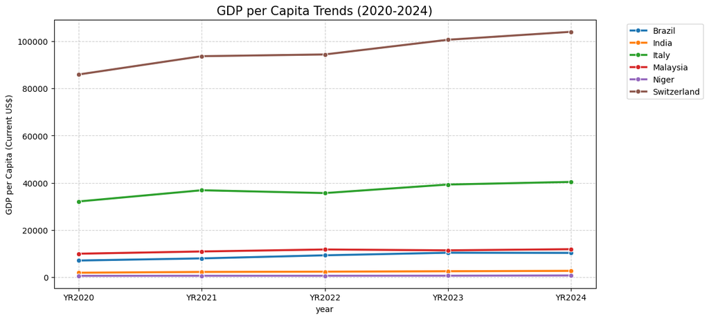

```python
import matplotlib.pyplot as plt
import seaborn as sns

file_path_long = '/Users/sissili/Desktop/QTM350/QTM_350_Final_Project/QTM350_Final_Project_Data/cleaned_final_project_data_long.csv'
df_long = pd.read_csv(file_path_long)

plt.figure(figsize=(12, 6))
sns.lineplot(data=df_long, x='year', y='gdp', hue='Country', marker='o', linewidth=2.5)
plt.title('GDP per Capita Trends (2020-2024)', fontsize=15)
plt.ylabel('GDP per Capita (Current US$)')
plt.grid(True, linestyle='--', alpha=0.6)
plt.legend(bbox_to_anchor=(1.05, 1), loc='upper left')
plt.show()
```

### Interpretaiton:

Italy serves as the upper-middle benchmark. It exhibits the most visible "recovery arc" after 2022. In contrast, Brazil and Malaysia show "parallel stagnation"—their lines are trending upward, but the slope is much shallower than Italy’s. This suggests that while Italy is successfully "rebounding" toward higher income levels, Brazil and Malaysia are experiencing a slower momentum, perhaps limited by different domestic economic constraints or resource dependencies.

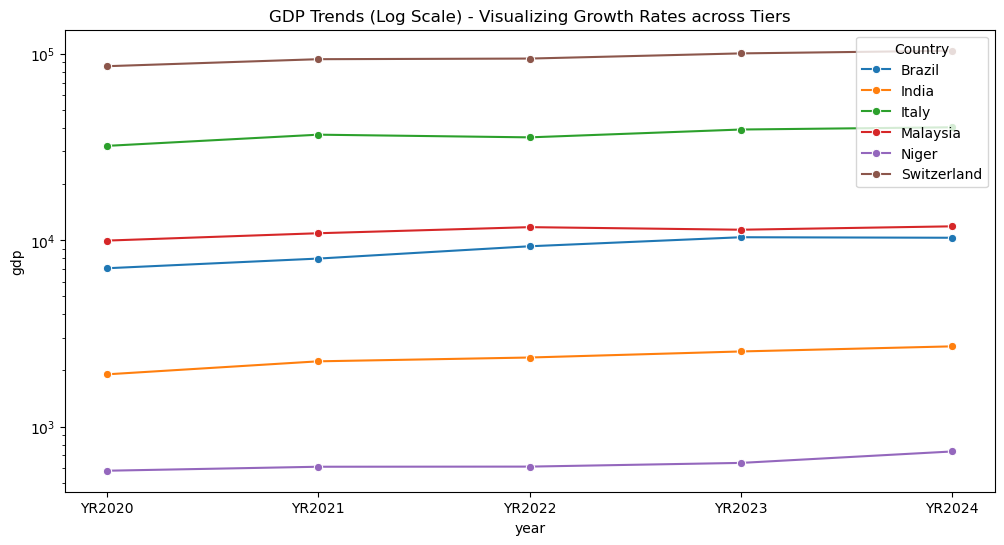

```python
plt.figure(figsize=(12, 6))
sns.lineplot(data=df_long, x='year', y='gdp', hue='Country', marker='o')
plt.yscale('log') # This is the magic line
plt.title('GDP Trends (Log Scale) - Visualizing Growth Rates across Tiers')
plt.show()
```

### Interpretaiton:

To prevent Switzerland from "squashing" the others, we changed the Y-axis to a Logarithmic Scale.

### 2. Education vs. Fertility

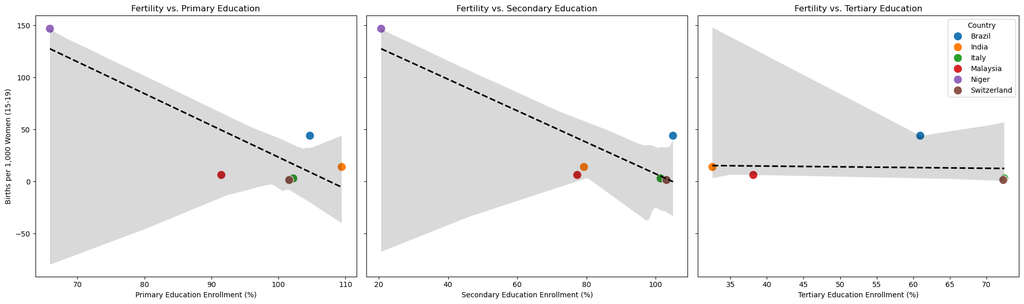

```python
import matplotlib.pyplot as plt
import seaborn as sns

# Set up a 3-panel figure
fig, axes = plt.subplots(1, 3, figsize=(20, 6), sharey=True)

# List of education variables to plot
edu_vars = ['primary_edu', 'secondary_edu', 'tertiary_edu']
titles = ['Primary Education', 'Secondary Education', 'Tertiary Education']

for i, var in enumerate(edu_vars):
    # Plot on the specific subplot axis
    sns.scatterplot(data=df, x=var, y='fertility', hue='Country',
                    s=150, ax=axes[i], legend=(i == 2)) # Legend only on last plot

    # Add regression line
    sns.regplot(data=df, x=var, y='fertility', scatter=False,
                color='black', line_kws={'linestyle':'--'}, ax=axes[i])

    axes[i].set_title(f'Fertility vs. {titles[i]}')
    axes[i].set_xlabel(f'{titles[i]} Enrollment (%)')
    if i == 0:
        axes[i].set_ylabel('Births per 1,000 Women (15-19)')

plt.tight_layout()
plt.show()
```

### Interpretation:

1. Primary Education: The Foundation (High Saturation)

The first pane shows that nearly all countries—except Niger—have achieved high primary enrollment (above 90%).

The Insight: Because Brazil, India, Malaysia, Italy, and Switzerland all cluster at the high end of primary school enrollment, this variable alone doesn't explain why their fertility rates differ so much. Primary education is a "baseline" requirement, but it isn't enough to drive adolescent fertility toward zero.

2. Secondary Education: The Critical Pivot (Strongest Correlation)

This is your most "telling" graph. You can see the countries begin to spread out significantly across the X-axis.

The Insight: There is a clear, steep diagonal relationship here. As enrollment moves from 20% (Niger) to 80% (India/Malaysia) to 100%+ (Italy/Switzerland), the fertility rate drops predictably. This suggests that keeping girls in school through their teenage years is the most effective deterrent to early childbirth among these variables.

3. Tertiary Education: The Developed World Luxury

In the final pane, we see a massive "data gap."

The Missing Link: Niger is absent here because tertiary data for the 2020–2024 period is often unavailable for ultra-low-income nations.

The Insight: For the countries that do have data, the trend line flattens significantly. This indicates that by the time a population reaches tertiary (college) level, adolescent fertility is already extremely low. Tertiary education is more of a characteristic of "High GDP" nations rather than a direct driver for reducing adolescent births (since most tertiary students are already past the age of 19).

Therefore, a comparative analysis of educational tiers suggests that Secondary Education Enrollment provides the most significant explanatory power for variations in adolescent fertility. While primary education has reached near-saturation in most studied nations, the divergence in secondary enrollment highlights a critical 'protection' window. The transition from primary to secondary school marks the point where economic opportunity and reproductive health outcomes most clearly align.

### Correlation Heatmap

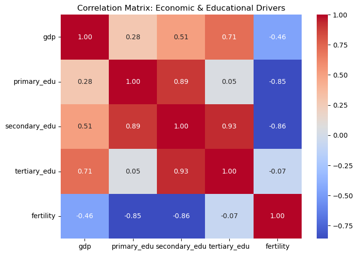

```python
# Create the correlation heatmap using the averaged data
plt.figure(figsize=(8, 6))
# Using only the core variables
corr_cols = ['gdp', 'primary_edu', 'secondary_edu', 'tertiary_edu', 'fertility']
sns.heatmap(df[corr_cols].corr(), annot=True, cmap='coolwarm', fmt=".2f")
plt.title('Correlation Matrix: Economic & Educational Drivers')
plt.show()
```

### Interpretation:

1. Secondary Education is the "Silver Bullet"

The correlation between secondary_edu and fertility is -0.86.

Interpretation: This is an incredibly strong negative relationship. It mathematically confirms that as secondary enrollment increases, adolescent fertility rates drop significantly. In fact, it is slightly stronger than the primary education correlation (-0.85), supporting your previous observation that secondary school is the critical "protection window."

2. The GDP Paradox

Notice that gdp has a much weaker correlation with fertility (-0.46) than education does.

Interpretation: This is a sophisticated finding! It suggests that wealth alone isn't what reduces adolescent fertility; rather, it’s what that wealth buys—specifically, access to education. A country can be moderately wealthy, but if it doesn't invest that wealth into schools, fertility rates may remain high.

3. The Tertiary "Drop Off"

The correlation between tertiary_edu and fertility is nearly zero (-0.07).

Interpretation: This confirms our previous graph interpretation. By the time women reach the age for university (tertiary), the "risk" period for adolescent fertility (ages 15–19) has mostly passed. Tertiary education is a sign of a developed economy, but it isn't the primary driver for reducing teenage births.

4. Education Levels Move Together

The high correlation between primary and secondary (0.89) and secondary and tertiary (0.93) shows that education is a pipeline. If a country successfully scales secondary education, it almost always sees a massive jump in tertiary readiness.

Therefore, the correlation matrix provides statistical validation for the study’s hypothesis. While GDP per capita shows a moderate negative correlation with adolescent fertility (-0.46), educational attainment—specifically at the secondary level—shows a far more profound impact (-0.86). This suggests that educational policy may be a more direct and effective lever for social change than general economic growth alone.

### Education & GDP

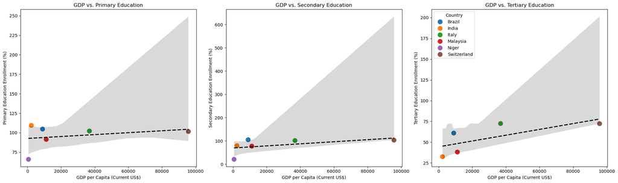

```python
# Set up a 3-panel figure for GDP vs Education
fig, axes = plt.subplots(1, 3, figsize=(20, 6), sharex=True)

edu_vars = ['primary_edu', 'secondary_edu', 'tertiary_edu']
titles = ['Primary Education', 'Secondary Education', 'Tertiary Education']

for i, var in enumerate(edu_vars):
    # Scatter plot
    sns.scatterplot(data=df, x='gdp', y=var, hue='Country',
                    s=150, ax=axes[i], legend=(i == 2))

    # Regression line
    sns.regplot(data=df, x='gdp', y=var, scatter=False,
                color='black', line_kws={'linestyle':'--'}, ax=axes[i])

    axes[i].set_title(f'GDP vs. {titles[i]}')
    axes[i].set_xlabel('GDP per Capita (Current US$)')
    axes[i].set_ylabel(f'{titles[i]} Enrollment (%)')

plt.tight_layout()
plt.show()
```

### Interpretation：

1. GDP vs. Primary Education: The Non-Negotiable Baseline

The regression line is nearly flat, with most countries clustered between 90% and 110% enrollment (the >100% values usually represent over-age students or repeaters).

Primary education is no longer a "luxury" tied to high GDP. Almost every nation in your study, from India to Switzerland, has hit near-saturation. Niger is the only clear outlier here, suggesting that at the lowest levels of wealth, even basic education access remains a struggle.

2. GDP vs. Secondary Education: The Linear Engine

This is the most "equitable" relationship. As nations move from low to middle income (moving from India/Niger toward Brazil/Malaysia/Italy), they see the most direct return on their wealth in terms of secondary school seats. This confirms that secondary education is the "bridge" that wealth builds to improve social outcomes.

3. GDP vs. Tertiary Education: The High-Income Differentiator

Unlike the other two plots, the tertiary graph shows significant "vertical" spread even among countries with lower GDPs.

### Findings from the analysis:

1. The Wealth-Education Pipeline

### Conclusion

Based on the descriptive evidence, Secondary Education Enrollment is the most influential factor in reducing adolescent fertility rates. While GDP per capita provides the necessary financial foundation to build and sustain school systems, it is the actual attainment of secondary education that acts as the functional mechanism for lowering fertility. Therefore, economic growth is most effective at improving social outcomes when it is specifically channeled into teenage educational retention.